# HappinessAnalysis

Fatmah Kabeer

10/11/2020

#### *In this document, I analyze a dataset that I have collected from Kaggle. This dataset illustrates the happiness in the world. I mainly focus on my analysis of the year 2019 as well as my country, Saudi Arabia.*

```r
happiness_2015 <- read.csv("archive/2015.csv")
happiness_2016 <- read.csv("archive/2016.csv")
happiness_2017 <- read.csv("archive/2017.csv")
happiness_2018 <- read.csv("archive/2018.csv")
happiness_2019 <- read.csv("archive/2019.csv")
```

### In 2019

#### First of all we need to know the comparisons criterias in 2019:

```r
dropN <- c("Country.or.region", "Overall.rank", "Score")
criteria <- names(happiness_2019[!(names(happiness_2019)) %in% dropN])

knitr::kable(criteria)
```

| x |
| --- |
| GDP.per.capita |
| Social.support |
| Healthy.life.expectancy |
| Freedom.to.make.life.choices |
| Generosity |
| Perceptions.of.corruption |

#### How many Countries in the evaluating list?

```r
nrow(happiness_2019)
```

```
## [1] 156
```

#### What are the top 10 of the happiest countries in 2019?

```r
happiest <- arrange(happiness_2019, Overall.rank)
happiest10 <- head(happiest$Country.or.region, 10)

knitr::kable(happiest10)
```

| x |
| --- |
| Finland |
| Denmark |
| Norway |
| Iceland |
| Netherlands |
| Switzerland |
| Sweden |
| New Zealand |
| Canada |
| Austria |

```r
saddest <- arrange(happiness_2019, desc(Overall.rank))
saddest10 <- head(saddest$Country.or.region, 10) %>%
   knitr::kable()
```

#### How freedom affect countries’ happiness in 2019?

**Plot to explain the relationship between freedom to make life choices with the level of happiness.** As we can see the population in the happiest countries is as showing kind of have a more degree of freedom to make life than others.

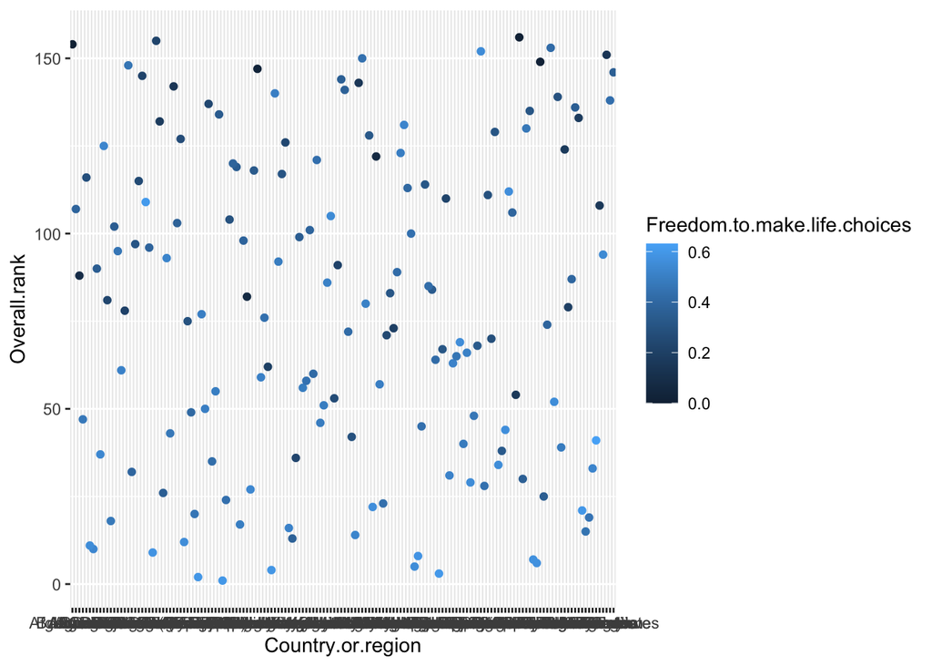

```r
ggplot(happiness_2019, aes(x = Country.or.region,
                           y = Overall.rank,
                           color = Freedom.to.make.life.choices)) +
  #facet_grid(Country.or.region ~ Social.support) +
  geom_point()
```

#### Comparison between the average Healthy Life Expectancy in the happiest against the saddest countries.

**The average of the Healthy Life Expectancy for the saddest country in 2019:**

```r
happiness_2019 %>%
  summarise(avg = mean(Healthy.life.expectancy[Overall.rank > (nrow(happiness_2019) - 10)]))
```

```
##      avg
## 1 0.4259
```

```r
happiness_2019 %>%
  summarise(avg = mean(Healthy.life.expectancy[Overall.rank > 10]))
```

```
##         avg
## 1 0.7052123
```

### Saudi Arabia:

**Saudi Arabia rank**

```r
sa2015 <- filter(happiness_2015, Country == "Saudi Arabia")
sa2016 <- filter(happiness_2016, Country == "Saudi Arabia")
sa2017 <- filter(happiness_2017, Country == "Saudi Arabia")
sa2018 <- filter(happiness_2018, Country.or.region == "Saudi Arabia")
sa2019 <- filter(happiness_2019, Country.or.region == "Saudi Arabia")
```

```r
saRank <- happiness_2019 %>%
  filter(Country.or.region == "Saudi Arabia")
saRank[1,1]
```

```
## [1] 28
```

#### Saudis Happiness details in 2019 in comparisons with the happiest country:

```r
SvsF <- filter(happiness_2019, Country.or.region == "Saudi Arabia" | Overall.rank == 1)
knitr::kable(SvsF)
```

| Overall.rank | Country.or.region | Score | GDP.per.capita | Social.support | Healthy.life.expectancy | Freedom.to.make.life.choices | Generosity | Perceptions.of.corruption |
| --- | --- | --- | --- | --- | --- | --- | --- | --- |
| 1 | Finland | 7.769 | 1.340 | 1.587 | 0.986 | 0.596 | 0.153 | 0.393 |
| 28 | Saudi Arabia | 6.375 | 1.403 | 1.357 | 0.795 | 0.439 | 0.080 | 0.132 |

[figure not shown]

#### How happiness’ rank in Saudi Arabia changed over the last five years:

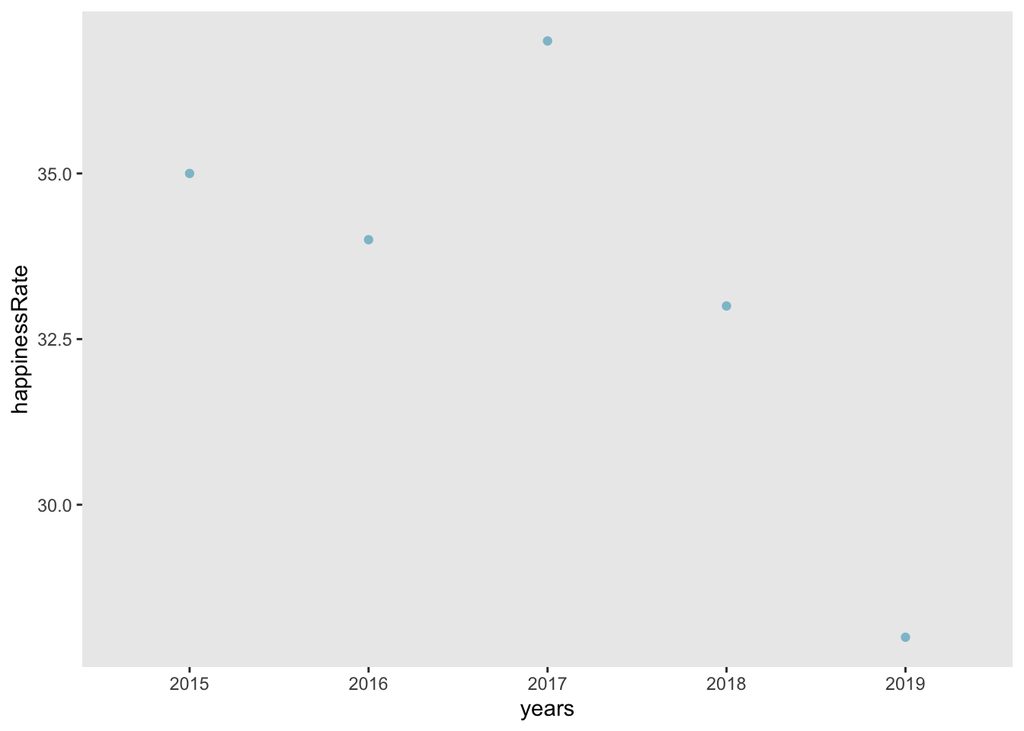

**Relation between Social Support and Ovarall.rank in 2018 and 2019:** As it is shown Social Support does not make a huge difference in Saudis’ happiness rate in the last two years.

```r
sociVsRank18 <- select(sa2018, c(Social.support,Overall.rank))
sociVsRank19 <- data.frame(Social.support = sa2019$Social.support,
                           Overall.rank = sa2019$Overall.rank)

sociVsRank18_19 <- rbind(sociVsRank18, sociVsRank19)
sociVsRank18_19$year <- c("2018", "2019")
knitr::kable(sociVsRank18_19)
```

| Social.support | Overall.rank | year |
| --- | --- | --- |
| 1.331 | 33 | 2018 |
| 1.357 | 28 | 2019 |

#### Saudis’ happiness details over the last two years:

```r
Sa19 <- data.frame(Overall.rank = sa2019$Overall.rank,
                       Country.or.region = sa2019$Country.or.region,
                       Score = sa2019$Score,
                       GDP.per.capita = sa2019$GDP.per.capita,
                       Social.support = sa2019$Social.support,
                       Healthy.life.expectancy = sa2019$Healthy.life.expectancy,
                       Freedom.to.make.life.choices = sa2019$Healthy.life.expectancy,
                       Generosity = sa2019$Generosity,
                       Perceptions.of.corruption = sa2019$Perceptions.of.corruption)


SaHappinessDf18_19 <- rbind(sa2018, Sa19)
SaHappinessDf18_19$year <- c("2018", "2019")
knitr::kable(SaHappinessDf18_19)
```

[output not shown]

#### Old data..

**2015**

```r
knitr::kable(sa2015)
```

| Country | Region | Happiness.Rank | Happiness.Score | Standard.Error | Economy..GDP.per.Capita. | Family | Health..Life.Expectancy. | Freedom | Trust..Government.Corruption. | Generosity | Dystopia.Residual |
| --- | --- | --- | --- | --- | --- | --- | --- | --- | --- | --- | --- |
| Saudi Arabia | Middle East and Northern Africa | 35 | 6.411 | 0.04633 | 1.39541 | 1.08393 | 0.72025 | 0.31048 | 0.32524 | 0.13706 | 2.43872 |

**2016**

```r
knitr::kable(sa2016)
```

| Country | Region | Happiness.Rank | Happiness.Score | Lower.Confidence.Interval | Upper.Confidence.Interval | Economy..GDP.per.Capita. | Family | Health..Life.Expectancy. | Freedom | Trust..Government.Corruption. | Generosity | Dystopia.Residual |
| --- | --- | --- | --- | --- | --- | --- | --- | --- | --- | --- | --- | --- |
| Saudi Arabia | Middle East and Northern Africa | 34 | 6.379 | 6.287 | 6.471 | 1.48953 | 0.84829 | 0.59267 | 0.37904 | 0.30008 | 0.15457 | 2.61482 |

**2017**

```r
knitr::kable(sa2017)
```

| Country | Happiness.Rank | Happiness.Score | Whisker.high | Whisker.low | Economy..GDP.per.Capita. | Family | Health..Life.Expectancy. | Freedom | Generosity | Trust..Government.Corruption. | Dystopia.Residual |
| --- | --- | --- | --- | --- | --- | --- | --- | --- | --- | --- | --- |
| Saudi Arabia | 37 | 6.344 | 6.444167 | 6.243833 | 1.530624 | 1.286678 | 0.5901483 | 0.4497506 | 0.147616 | 0.2734323 | 2.06543 |